# Unit 3 task 1

José Rodríguez Maldonado

January de 2018

## Create a Kaplan-Meir survival curve

Using the R package survival generate survival data and plot a K-M curve for the data shown in the table. Check analytically the observed values using the Equation from the slides.

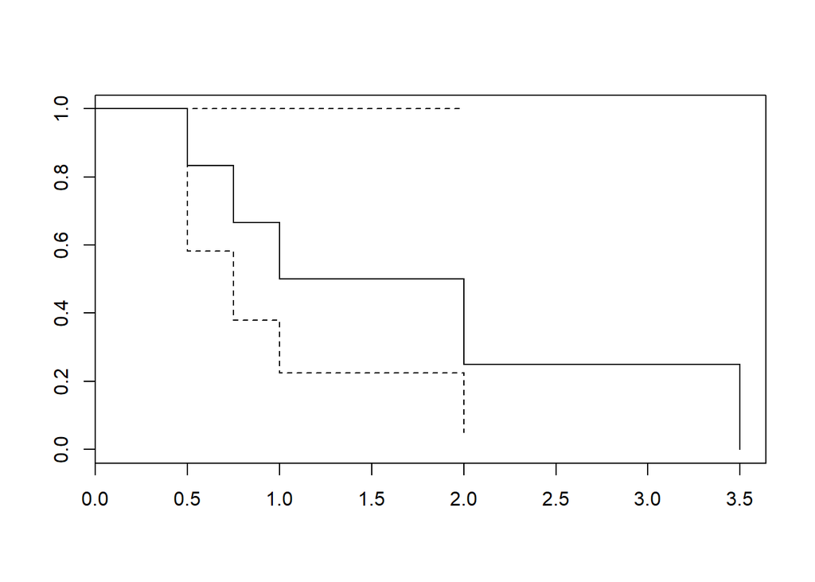

```r
library(survival)
events = c(1,1,1,0,1,1)
time = c(0.5, 0.75, 1, 1.5, 2, 3.5)
plot(survfit(Surv(time,events)~1))
```

If we compare the curve obtained with the results that we have:

[figure not shown]

## Create a Cox regression model

Use the dataset lung and make a prediction on some novel cases. Compute a survival curve with the predictions obtained from two different groups (i.e, groups with age lower than 60 and older than 60).

I am going to use the **lung** dataset. We can find it in the survival package, and to use it, we just have to write `lung`.

I am going to start with the example proposed.

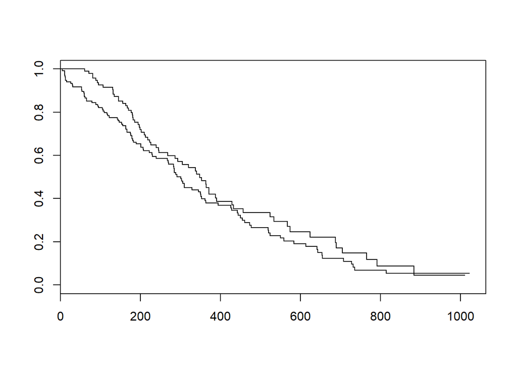

```r
df<-lung
df$age<-cut(lung$age, breaks = c(1,60,100))
plot(survfit(Surv(time,status)~age, df))
```

We can improve this graph using *ggsurvplot*:

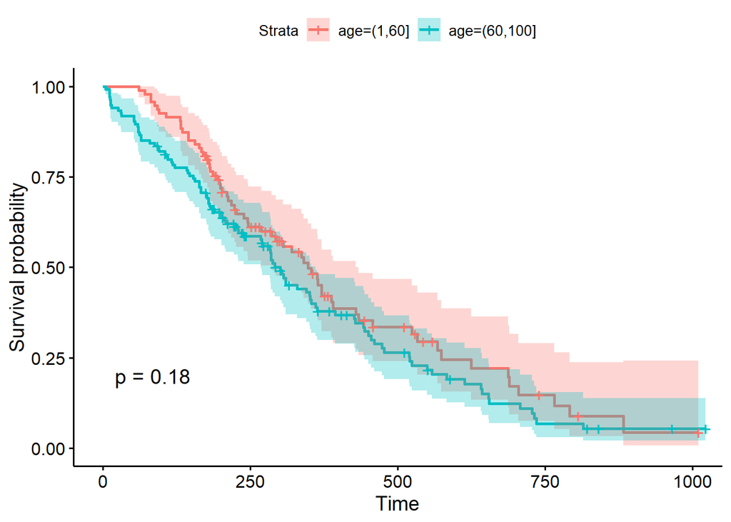

```r
ggsurvplot(survfit(Surv(time,status)~age, df), conf.int = TRUE, censor= TRUE, cex.axis=3, cex.lab=3.0, main="Survival curve Age grouping", pval = TRUE)
```

As we can see, we do not have a meaningful difference between this two curves. We can check another parameter, for example, **sex**. We get a meaningful difference between the curves. Which means, we can find groups of patients with sirvivals more different between them using the sex to separate the patients, in stead of the age ranges.

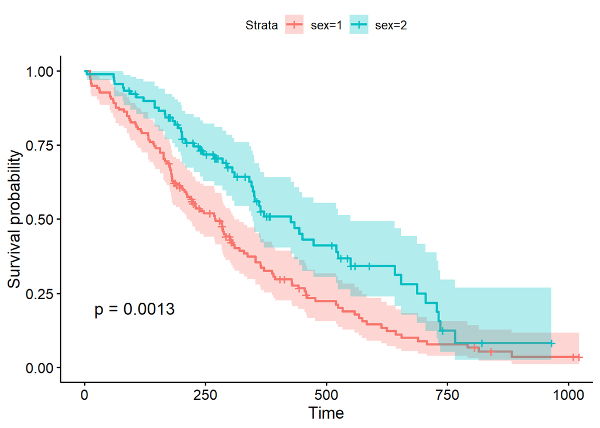

```r
ggsurvplot(survfit(Surv(time,status)~sex, df), conf.int = TRUE, censor= TRUE, cex.axis=3, cex.lab=3.0, main="Survival curve Age grouping", pval = TRUE)
```

## Summary of Ref. [P3-R1]

Write with your own words a short summary of the most relevant methods and findings of this work. *[P3-R1] Van ’t Veer L.J., Dai H., Van de Vijver M.J., et al. Gene expression profiling predicts clinical outcome of breast cancer. Nature, 415, pp. 530-536 (2002).*

#### Summary.

The paper aims to find a strategy to select patients who would benefit from adjuvant therapy.

First of all, 98 primary breast cancers were selected. After the lab work, they end up having about 5000 genes that were significantly regulated across the group of samples. Then, an unsupervised hierarchical clustering allowed them to cluster the 98 tumors according to their similarity measures. The 5000 genes were clustered over 98 groups, where we can see two dominant types of tumors. Thus, using unsupervised clustering we can already distinguish between good and poor prognosis. To gain insight of this groups, histopathological data was associated. They conclude saying that unsupervised learning detects two subgroups of breast cancers, which differ in ER status and lymphocytic infiltration.

Afterwards, a three-step supervised clasification was applied:

- From the 25000 genes 231 were significantly associated with the disease.
- These genes were ordered.
- Optimize the number of genes in the ‘prognosis classifier’.

The functional anotation for the genes provides insight into the underlying biological mechanism leading to rapid metastases. To validate prognosis classifier, an additional set of primary tumors from 19 young, lymph-node-negative breast cancer patients was selected. The prediction of the classifier presented would indicate that women under 55with poor prognosis have a 28-fold odds to develop a distant metastasis within 5 years.

To investigate the expression patterns associated with the immunohistochemical staining of ER a two layer classification was performed. They observed with supervised learning, is that ER has predictive power for prognosis. Their results end up indicating that breast cancer prognosis can already be derived from the gene expression profile of the primary tumour. Finally, they applied the St. Gallen and NIH cinsensus criteria on our patient group. And we saw that it can select just as effectively those high-risk, and reduces significantly the unnecesary treatment.